# Biostat 203B Homework 5

Due Mar 22 @ 11:59PM

Author

Yue Wang UID:005704481

## Predicting ICU duration

Using the ICU cohort `mimiciv_icu_cohort.rds` you built in Homework 4, develop at least three machine learning approaches (logistic regression with enet regularization, random forest, boosting, SVM, MLP, etc) plus a model stacking approach for predicting whether a patient’s ICU stay will be longer than 2 days. You should use the `los_long` variable as the outcome. You algorithms can use patient demographic information (gender, age at ICU `intime`, marital status, race), ICU admission information (first care unit), the last lab measurements before the ICU stay, and first vital measurements during ICU stay as features. You are welcome to use any feature engineering techniques you think are appropriate; but make sure to not use features that are not available at an ICU stay’s `intime`. For instance, `last_careunit` cannot be used in your algorithms.

1. Data preprocessing and feature engineering.

```r
library(GGally)
library(gtsummary)
library(tidyverse)
library(tidymodels)
library(ranger)
library(glmnet)
library(xgboost)
library(stacks)
library(keras)
library(randomForest)
```

```r
mimic_icu_cohort <- readRDS("mimic_icu_cohort.rds") %>%
  select(los_long, gender, age_at_intime, marital_status, race,
         first_careunit, creatinine, sodium, chloride, bicarbonate,
         'white blood cell count', glucose, potassium, hematocrit,
         'systolic non-invasive blood pressure',
         'body temperature in Fahrenheit',
         'respiratory rate', 'diastolic non-invasive blood pressure',
         'heart rate', subject_id, hadm_id, stay_id) %>%
  print(width = Inf)
```

```
# A tibble: 73,181 × 22
   los_long gender age_at_intime marital_status race  first_careunit creatinine
   <lgl>    <chr>          <int> <chr>          <fct> <fct>               <dbl>
 1 FALSE    M                 33 MARRIED        WHITE Other                NA
 2 TRUE     F                 83 DIVORCED       WHITE Other                 0.6
 3 FALSE    M                 20 SINGLE         Other Other                NA
 4 FALSE    F                 38 SINGLE         Other Other                 0.7
 5 FALSE    M                 65 <NA>           ASIAN Other                NA
 6 FALSE    F                 68 SINGLE         WHITE Other                NA
 7 FALSE    F                 74 SINGLE         WHITE Other                 0.8
 8 FALSE    F                 73 SINGLE         WHITE Other                 0.9
 9 TRUE     M                 58 MARRIED        WHITE Other                 0.8
10 TRUE     M                 58 MARRIED        WHITE Other                 0.6
   sodium chloride bicarbonate `white blood cell count` glucose potassium
    <dbl>    <dbl>       <dbl>                    <dbl>   <dbl>     <dbl>
```

[output cut: 59 more lines]

```r
mimic_icu_cohort$los_long <- as.factor(mimic_icu_cohort$los_long)
```

```r
mimic_icu_cohort %>% tbl_summary(by = los_long)
```

| **Characteristic** | **FALSE**, N = 38,050<sup>1</sup> | **TRUE**, N = 35,131<sup>1</sup> |
| --- | --- | --- |
| gender |  |  |
| F | 17,014 (45%) | 15,349 (44%) |
| M | 21,036 (55%) | 19,782 (56%) |
| age_at_intime | 65 (53, 77) | 67 (56, 78) |
| marital_status |  |  |
| DIVORCED | 2,843 (8.0%) | 2,561 (7.9%) |
| MARRIED | 16,984 (48%) | 15,784 (49%) |
| SINGLE | 11,175 (31%) | 9,683 (30%) |
| WIDOWED | 4,699 (13%) | 4,339 (13%) |
| Unknown | 2,349 | 2,764 |
| race |  |  |
| Other | 5,160 (14%) | 5,596 (16%) |
| ASIAN | 1,148 (3.0%) | 1,007 (2.9%) |
| BLACK | 4,311 (11%) | 3,649 (10%) |
| HISPANIC | 1,492 (3.9%) | 1,249 (3.6%) |
| WHITE | 25,939 (68%) | 23,630 (67%) |
| first_careunit |  |  |
| Cardiac Vascular Intensive Care Unit (CVICU) | 5,827 (15%) | 5,755 (16%) |
| Medical Intensive Care Unit (MICU) | 8,782 (23%) | 7,116 (20%) |
| Medical/Surgical Intensive Care Unit (MICU/SICU) | 7,147 (19%) | 5,586 (16%) |
| Surgical Intensive Care Unit (SICU) | 5,654 (15%) | 5,507 (16%) |
| Other | 10,640 (28%) | 11,167 (32%) |
| creatinine | 1.00 (0.80, 1.40) | 1.00 (0.80, 1.60) |
| Unknown | 2,590 | 3,164 |
| sodium | 139.0 (136.0, 141.0) | 138.0 (135.0, 141.0) |
| Unknown | 4,165 | 4,693 |
| chloride | 102 (98, 105) | 102 (98, 105) |
| Unknown | 4,166 | 4,703 |
| bicarbonate | 25.0 (22.0, 27.0) | 24.0 (21.0, 27.0) |
| Unknown | 4,262 | 4,773 |
| white blood cell count | 9.0 (6.6, 12.6) | 9.7 (7.0, 13.8) |
| Unknown | 2,271 | 2,821 |
| glucose | 118 (98, 153) | 122 (100, 159) |
| Unknown | 4,274 | 4,810 |
| potassium | 4.20 (3.80, 4.60) | 4.20 (3.80, 4.70) |
| Unknown | 4,182 | 4,706 |
| hematocrit | 36 (30, 40) | 35 (29, 40) |
| Unknown | 2,235 | 2,780 |
| systolic non-invasive blood pressure | 122 (107, 139) | 120 (104, 138) |
| Unknown | 732 | 247 |
| body temperature in Fahrenheit | 98.10 (97.60, 98.60) | 98.20 (97.60, 98.80) |
| Unknown | 1,189 | 173 |
| respiratory rate | 18.0 (15.0, 22.0) | 19.0 (15.0, 23.0) |
| Unknown | 87 | 11 |
| diastolic non-invasive blood pressure | 68 (58, 80) | 66 (55, 79) |
| Unknown | 733 | 250 |
| heart rate | 85 (74, 99) | 88 (76, 103) |
| Unknown | 17 | 1 |
| subject_id | 15,002,798 (12,488,949, 17,523,219) | 14,995,832 (12,498,337, 17,496,102) |
| hadm_id | 24,949,943 (22,469,194, 27,466,877) | 24,995,222 (22,499,999, 27,473,223) |
| stay_id | 35,026,375 (32,509,262, 37,504,248) | 34,960,130 (32,470,375, 37,471,693) |

<sup>1</sup> n (%); Median (IQR)

2. Partition data into 50% training set and 50% test set. Stratify partitioning according to `los_long`. For grading purpose, sort the data by `subject_id`, `hadm_id`, and `stay_id` and use the seed `203` for the initial data split. Below is the sample code.

```r
# sort
mimic_icu_cohort <- mimic_icu_cohort %>%
  arrange(subject_id, hadm_id, stay_id)

data_split <- initial_split(
  mimic_icu_cohort,
  # stratify by los_long
  strata = "los_long",
  prop = 0.5
  )
```

```r
mimic_other <- training(data_split)
dim(mimic_other)
```

```
[1] 36590    22
```

```r
mimic_test <- testing(data_split)
dim(mimic_test)
```

```
[1] 36591    22
```

**Answer:** There are missing values in ‘marital_status’, lab measurements and vital measurements, so we will use the imputation.

```r
# Recipe
mimic_recipe <-
  recipe(
    los_long ~ .,
    data = mimic_other
  ) %>%
  # imputation
  step_impute_mean(creatinine, sodium, chloride, bicarbonate,
         'white blood cell count', glucose, potassium, hematocrit,
         'systolic non-invasive blood pressure',
         'body temperature in Fahrenheit',
         'respiratory rate', 'diastolic non-invasive blood pressure',
         'heart rate') %>%
  step_impute_mode(marital_status) %>%
  # create traditional dummy variables
  step_dummy(all_nominal_predictors()) %>%
  # zero-variance filter
  step_zv(all_numeric_predictors()) %>%
  # center and scale numeric data
  step_normalize(all_numeric_predictors()) %>%
  # estimate the means and standard deviations
  # prep(training = Heart_other, retain = TRUE) %>%
  print()
```

```
── Recipe ──────────────────────────────────────────────────────────────────────
```

```
── Inputs
```

```
Number of variables by role
```

```
outcome:    1
predictor: 21
```

```
── Operations
```

```
• Mean imputation for: creatinine, sodium, chloride, bicarbonate, ...
```

```
• Mode imputation for: marital_status
```

```
• Dummy variables from: all_nominal_predictors()
```

```
• Zero variance filter on: all_numeric_predictors()
```

```
• Centering and scaling for: all_numeric_predictors()
```

3. Train and tune the models using the training set.
4. Compare model classification performance on the test set. Report both the area under ROC curve and accuracy for each machine learning algorithm and the model stacking. Interpret the results. What are the most important features in predicting long ICU stays? How do the models compare in terms of performance and interpretability?

**Answer:** 1. Logistic Regression

```r
# Model
logit_mod <-
  logistic_reg(
    penalty = tune(),
    mixture = tune()
  ) %>%
  set_engine("glmnet", standardize = FALSE) %>%
  print()
```

```
Logistic Regression Model Specification (classification)

Main Arguments:
  penalty = tune()
  mixture = tune()

Engine-Specific Arguments:
  standardize = FALSE

Computational engine: glmnet
```

```r
# Workflow
logit_wf <- workflow() %>%
  add_recipe(mimic_recipe) %>%
  add_model(logit_mod)
logit_wf
```

```
══ Workflow ════════════════════════════════════════════════════════════════════
Preprocessor: Recipe
Model: logistic_reg()

── Preprocessor ────────────────────────────────────────────────────────────────
5 Recipe Steps

• step_impute_mean()
• step_impute_mode()
• step_dummy()
• step_zv()
• step_normalize()

── Model ───────────────────────────────────────────────────────────────────────
Logistic Regression Model Specification (classification)

Main Arguments:
  penalty = tune()
  mixture = tune()

Engine-Specific Arguments:
  standardize = FALSE

Computational engine: glmnet
```

```r
# grid
param_grid_logit <- grid_regular(
  penalty(range = c(-6, 3)),
  mixture(),
  levels = c(100, 5)
  ) %>%
  print()
```

```
# A tibble: 500 × 2
      penalty mixture
        <dbl>   <dbl>
 1 0.000001         0
 2 0.00000123       0
 3 0.00000152       0
 4 0.00000187       0
 5 0.00000231       0
 6 0.00000285       0
 7 0.00000351       0
 8 0.00000433       0
 9 0.00000534       0
10 0.00000658       0
# ℹ 490 more rows
```

```r
# CV
set.seed(203)

folds_logit <- vfold_cv(mimic_other, v = 5)
folds_logit
```

```
#  5-fold cross-validation
# A tibble: 5 × 2
  splits               id
  <list>               <chr>
1 <split [29272/7318]> Fold1
2 <split [29272/7318]> Fold2
3 <split [29272/7318]> Fold3
4 <split [29272/7318]> Fold4
5 <split [29272/7318]> Fold5
```

```r
(logit_fit <- logit_wf %>%
  tune_grid(
    resamples = folds_logit,
    grid = param_grid_logit,
    metrics = metric_set(roc_auc, accuracy)
    )) %>%
  system.time()
```

```
   user  system elapsed
 36.273   0.230  36.515
```

```r
logit_fit
```

```
# Tuning results
# 5-fold cross-validation
# A tibble: 5 × 4
  splits               id    .metrics             .notes
  <list>               <chr> <list>               <list>
1 <split [29272/7318]> Fold1 <tibble [1,000 × 6]> <tibble [0 × 3]>
2 <split [29272/7318]> Fold2 <tibble [1,000 × 6]> <tibble [0 × 3]>
3 <split [29272/7318]> Fold3 <tibble [1,000 × 6]> <tibble [0 × 3]>
4 <split [29272/7318]> Fold4 <tibble [1,000 × 6]> <tibble [0 × 3]>
5 <split [29272/7318]> Fold5 <tibble [1,000 × 6]> <tibble [0 × 3]>
```

```
# A tibble: 1,000 × 8
      penalty mixture .metric  .estimator  mean     n std_err
        <dbl>   <dbl> <chr>    <chr>      <dbl> <int>   <dbl>
 1 0.000001         0 accuracy binary     0.574     5 0.00237
 2 0.000001         0 roc_auc  binary     0.599     5 0.00100
 3 0.00000123       0 accuracy binary     0.574     5 0.00237
 4 0.00000123       0 roc_auc  binary     0.599     5 0.00100
 5 0.00000152       0 accuracy binary     0.574     5 0.00237
 6 0.00000152       0 roc_auc  binary     0.599     5 0.00100
 7 0.00000187       0 accuracy binary     0.574     5 0.00237
 8 0.00000187       0 roc_auc  binary     0.599     5 0.00100
 9 0.00000231       0 accuracy binary     0.574     5 0.00237
10 0.00000231       0 roc_auc  binary     0.599     5 0.00100
   .config
   <chr>
 1 Preprocessor1_Model001
 2 Preprocessor1_Model001
 3 Preprocessor1_Model002
 4 Preprocessor1_Model002
 5 Preprocessor1_Model003
 6 Preprocessor1_Model003
 7 Preprocessor1_Model004
 8 Preprocessor1_Model004
 9 Preprocessor1_Model005
10 Preprocessor1_Model005
# ℹ 990 more rows
```

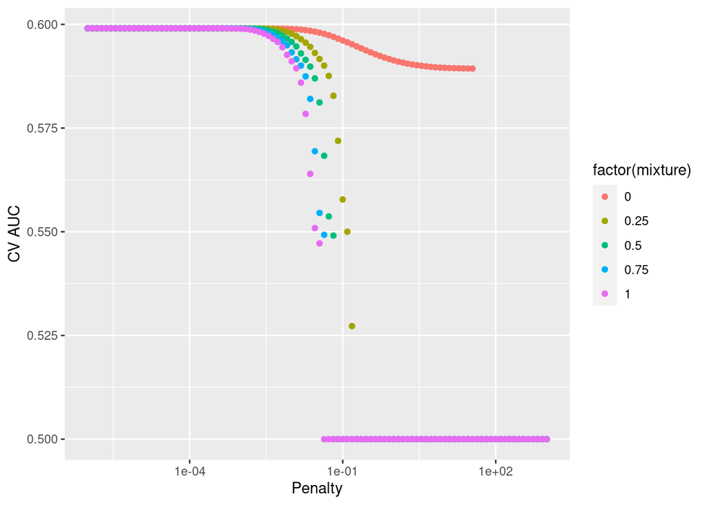

```r
logit_fit %>%
  collect_metrics() %>%
  print(width = Inf) %>%
  filter(.metric == "roc_auc") %>%
  ggplot(mapping = aes(x = penalty, y = mean, color = factor(mixture))) +
  geom_point() +
  labs(x = "Penalty", y = "CV AUC") +
  scale_x_log10()
```

```r
logit_fit %>%
  show_best("roc_auc")
```

```
# A tibble: 5 × 8
     penalty mixture .metric .estimator  mean     n  std_err .config
       <dbl>   <dbl> <chr>   <chr>      <dbl> <int>    <dbl> <chr>
1 0.000001      0.25 roc_auc binary     0.599     5 0.000922 Preprocessor1_Mode…
2 0.00000123    0.25 roc_auc binary     0.599     5 0.000922 Preprocessor1_Mode…
3 0.00000152    0.25 roc_auc binary     0.599     5 0.000922 Preprocessor1_Mode…
4 0.00000187    0.25 roc_auc binary     0.599     5 0.000922 Preprocessor1_Mode…
5 0.00000231    0.25 roc_auc binary     0.599     5 0.000922 Preprocessor1_Mode…
```

```r
best_logit <- logit_fit %>%
  select_best("roc_auc")
best_logit
```

```
# A tibble: 1 × 3
   penalty mixture .config
     <dbl>   <dbl> <chr>
1 0.000001    0.25 Preprocessor1_Model101
```

```r
# Final workflow
final_wf_logit <- logit_wf %>%
  finalize_workflow(best_logit)
final_wf_logit
```

```
══ Workflow ════════════════════════════════════════════════════════════════════
Preprocessor: Recipe
Model: logistic_reg()

── Preprocessor ────────────────────────────────────────────────────────────────
5 Recipe Steps

• step_impute_mean()
• step_impute_mode()
• step_dummy()
• step_zv()
• step_normalize()

── Model ───────────────────────────────────────────────────────────────────────
Logistic Regression Model Specification (classification)

Main Arguments:
  penalty = 1e-06
  mixture = 0.25

Engine-Specific Arguments:
  standardize = FALSE

Computational engine: glmnet
```

```r
# Fit the whole training set, then predict the test cases
final_fit_logit <-
  final_wf_logit %>%
  last_fit(data_split)
final_fit_logit
```

```
# Resampling results
# Manual resampling
# A tibble: 1 × 6
  splits                id             .metrics .notes   .predictions .workflow
  <list>                <chr>          <list>   <list>   <list>       <list>
1 <split [36590/36591]> train/test sp… <tibble> <tibble> <tibble>     <workflow>
```

The area under ROC curve and the accuracy for logistic regression model are shown below:

```r
# Test metrics
final_fit_logit %>%
  collect_metrics()
```

```
# A tibble: 2 × 4
  .metric  .estimator .estimate .config
  <chr>    <chr>          <dbl> <chr>
1 accuracy binary         0.573 Preprocessor1_Model1
2 roc_auc  binary         0.597 Preprocessor1_Model1
```

**Answer:** 2. Random Forest

```r
# Model
rf_mod <-
  rand_forest(
    mode = "classification",
    mtry = tune(),
    trees = tune()
  ) %>%
  set_engine("ranger")
rf_mod
```

```
Random Forest Model Specification (classification)

Main Arguments:
  mtry = tune()
  trees = tune()

Computational engine: ranger
```

```r
# Workflow
rf_wf <- workflow() %>%
  add_recipe(mimic_recipe) %>%
  add_model(rf_mod)
rf_wf
```

```
══ Workflow ════════════════════════════════════════════════════════════════════
Preprocessor: Recipe
Model: rand_forest()

── Preprocessor ────────────────────────────────────────────────────────────────
5 Recipe Steps

• step_impute_mean()
• step_impute_mode()
• step_dummy()
• step_zv()
• step_normalize()

── Model ───────────────────────────────────────────────────────────────────────
Random Forest Model Specification (classification)

Main Arguments:
  mtry = tune()
  trees = tune()

Computational engine: ranger
```

```r
param_grid_rf <- grid_regular(
  trees(range = c(80L, 120L)),
  mtry(range = c(1L, 5L)),
  levels = c(3, 3)
  )
param_grid_rf
```

```
# A tibble: 9 × 2
  trees  mtry
  <int> <int>
1    80     1
2   100     1
3   120     1
4    80     3
5   100     3
6   120     3
7    80     5
8   100     5
9   120     5
```

```r
set.seed(203)

folds_rf <- vfold_cv(mimic_other, v = 5)
folds_rf
```

```
#  5-fold cross-validation
# A tibble: 5 × 2
  splits               id
  <list>               <chr>
1 <split [29272/7318]> Fold1
2 <split [29272/7318]> Fold2
3 <split [29272/7318]> Fold3
4 <split [29272/7318]> Fold4
5 <split [29272/7318]> Fold5
```

```r
rf_fit <- rf_wf %>%
  tune_grid(
    resamples = folds_rf,
    grid = param_grid_rf,
    metrics = metric_set(roc_auc, accuracy)
    )
rf_fit
```

```
# Tuning results
# 5-fold cross-validation
# A tibble: 5 × 4
  splits               id    .metrics          .notes
  <list>               <chr> <list>            <list>
1 <split [29272/7318]> Fold1 <tibble [18 × 6]> <tibble [0 × 3]>
2 <split [29272/7318]> Fold2 <tibble [18 × 6]> <tibble [0 × 3]>
3 <split [29272/7318]> Fold3 <tibble [18 × 6]> <tibble [0 × 3]>
4 <split [29272/7318]> Fold4 <tibble [18 × 6]> <tibble [0 × 3]>
5 <split [29272/7318]> Fold5 <tibble [18 × 6]> <tibble [0 × 3]>
```

```
# A tibble: 18 × 8
    mtry trees .metric  .estimator  mean     n  std_err .config
   <int> <int> <chr>    <chr>      <dbl> <int>    <dbl> <chr>
 1     1    80 accuracy binary     0.579     5 0.00354  Preprocessor1_Model1
 2     1    80 roc_auc  binary     0.617     5 0.000536 Preprocessor1_Model1
 3     1   100 accuracy binary     0.580     5 0.00374  Preprocessor1_Model2
 4     1   100 roc_auc  binary     0.619     5 0.00173  Preprocessor1_Model2
 5     1   120 accuracy binary     0.581     5 0.00323  Preprocessor1_Model3
 6     1   120 roc_auc  binary     0.619     5 0.00181  Preprocessor1_Model3
 7     3    80 accuracy binary     0.586     5 0.000576 Preprocessor1_Model4
 8     3    80 roc_auc  binary     0.620     5 0.00198  Preprocessor1_Model4
 9     3   100 accuracy binary     0.589     5 0.00121  Preprocessor1_Model5
10     3   100 roc_auc  binary     0.624     5 0.00138  Preprocessor1_Model5
11     3   120 accuracy binary     0.588     5 0.00300  Preprocessor1_Model6
12     3   120 roc_auc  binary     0.622     5 0.00349  Preprocessor1_Model6
13     5    80 accuracy binary     0.584     5 0.00311  Preprocessor1_Model7
14     5    80 roc_auc  binary     0.619     5 0.00301  Preprocessor1_Model7
15     5   100 accuracy binary     0.588     5 0.00146  Preprocessor1_Model8
16     5   100 roc_auc  binary     0.622     5 0.00184  Preprocessor1_Model8
17     5   120 accuracy binary     0.589     5 0.00247  Preprocessor1_Model9
18     5   120 roc_auc  binary     0.624     5 0.00229  Preprocessor1_Model9
```

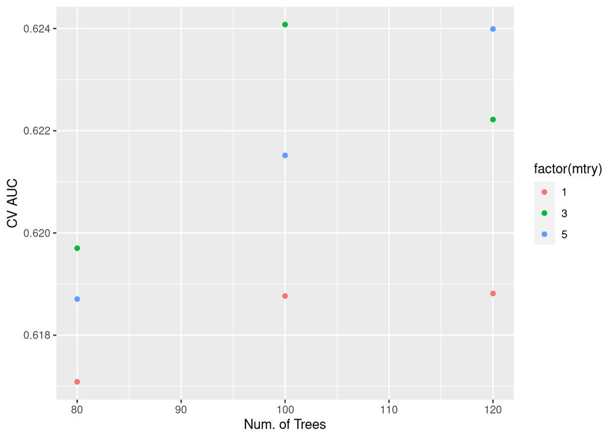

```r
rf_fit %>%
  collect_metrics() %>%
  print(width = Inf) %>%
  filter(.metric == "roc_auc") %>%
  ggplot(mapping = aes(x = trees, y = mean, color = factor(mtry))) +
  geom_point() +
  # geom_line() +
  labs(x = "Num. of Trees", y = "CV AUC")
```

```r
rf_fit %>%
  show_best("roc_auc")
```

```
# A tibble: 5 × 8
   mtry trees .metric .estimator  mean     n std_err .config
  <int> <int> <chr>   <chr>      <dbl> <int>   <dbl> <chr>
1     3   100 roc_auc binary     0.624     5 0.00138 Preprocessor1_Model5
2     5   120 roc_auc binary     0.624     5 0.00229 Preprocessor1_Model9
3     3   120 roc_auc binary     0.622     5 0.00349 Preprocessor1_Model6
4     5   100 roc_auc binary     0.622     5 0.00184 Preprocessor1_Model8
5     3    80 roc_auc binary     0.620     5 0.00198 Preprocessor1_Model4
```

```r
best_rf <- rf_fit %>%
  select_best("roc_auc")
best_rf
```

```
# A tibble: 1 × 3
   mtry trees .config
  <int> <int> <chr>
1     3   100 Preprocessor1_Model5
```

```r
# Final workflow
final_wf_rf <- rf_wf %>%
  finalize_workflow(best_rf)
final_wf_rf
```

```
══ Workflow ════════════════════════════════════════════════════════════════════
Preprocessor: Recipe
Model: rand_forest()

── Preprocessor ────────────────────────────────────────────────────────────────
5 Recipe Steps

• step_impute_mean()
• step_impute_mode()
• step_dummy()
• step_zv()
• step_normalize()

── Model ───────────────────────────────────────────────────────────────────────
Random Forest Model Specification (classification)

Main Arguments:
  mtry = 3
  trees = 100

Computational engine: ranger
```

```r
final_fit_rf <-
  final_wf_rf %>%
  last_fit(data_split)
final_fit_rf
```

```
# Resampling results
# Manual resampling
# A tibble: 1 × 6
  splits                id             .metrics .notes   .predictions .workflow
  <list>                <chr>          <list>   <list>   <list>       <list>
1 <split [36590/36591]> train/test sp… <tibble> <tibble> <tibble>     <workflow>
```

The area under ROC curve and the accuracy for random forest model are shown below:

```r
final_fit_rf %>%
  collect_metrics()
```

```
# A tibble: 2 × 4
  .metric  .estimator .estimate .config
  <chr>    <chr>          <dbl> <chr>
1 accuracy binary         0.586 Preprocessor1_Model1
2 roc_auc  binary         0.623 Preprocessor1_Model1
```

**Answer:** 3. XGBoost

```r
gb_mod <-
  boost_tree(
    mode = "classification",
    trees = 1000,
    tree_depth = tune(),
    learn_rate = tune()
  ) %>%
  set_engine("xgboost")
gb_mod
```

```
Boosted Tree Model Specification (classification)

Main Arguments:
  trees = 1000
  tree_depth = tune()
  learn_rate = tune()

Computational engine: xgboost
```

```r
gb_wf <- workflow() %>%
  add_recipe(mimic_recipe) %>%
  add_model(gb_mod)
gb_wf
```

```
══ Workflow ════════════════════════════════════════════════════════════════════
Preprocessor: Recipe
Model: boost_tree()

── Preprocessor ────────────────────────────────────────────────────────────────
5 Recipe Steps

• step_impute_mean()
• step_impute_mode()
• step_dummy()
• step_zv()
• step_normalize()

── Model ───────────────────────────────────────────────────────────────────────
Boosted Tree Model Specification (classification)

Main Arguments:
  trees = 1000
  tree_depth = tune()
  learn_rate = tune()

Computational engine: xgboost
```

```r
param_grid_gb <- grid_regular(
  tree_depth(range = c(1L, 3L)),
  learn_rate(range = c(-5, 2), trans = log10_trans()),
  levels = c(3, 3)
  )
param_grid_gb
```

```
# A tibble: 9 × 2
  tree_depth learn_rate
       <int>      <dbl>
1          1    0.00001
2          2    0.00001
3          3    0.00001
4          1    0.0316
5          2    0.0316
6          3    0.0316
7          1  100
8          2  100
9          3  100
```

```r
set.seed(203)

folds_gb <- vfold_cv(mimic_other, v = 3)
folds_gb
```

```
#  3-fold cross-validation
# A tibble: 3 × 2
  splits                id
  <list>                <chr>
1 <split [24393/12197]> Fold1
2 <split [24393/12197]> Fold2
3 <split [24394/12196]> Fold3
```

```r
gb_fit <- gb_wf %>%
  tune_grid(
    resamples = folds_gb,
    grid = param_grid_gb,
    metrics = metric_set(roc_auc, accuracy)
    )
gb_fit
```

```
# Tuning results
# 3-fold cross-validation
# A tibble: 3 × 4
  splits                id    .metrics          .notes
  <list>                <chr> <list>            <list>
1 <split [24393/12197]> Fold1 <tibble [18 × 6]> <tibble [0 × 3]>
2 <split [24393/12197]> Fold2 <tibble [18 × 6]> <tibble [0 × 3]>
3 <split [24394/12196]> Fold3 <tibble [18 × 6]> <tibble [0 × 3]>
```

```
# A tibble: 18 × 8
   tree_depth learn_rate .metric  .estimator  mean     n  std_err
        <int>      <dbl> <chr>    <chr>      <dbl> <int>    <dbl>
 1          1    0.00001 accuracy binary     0.542     3 0.00463
 2          1    0.00001 roc_auc  binary     0.532     3 0.00420
 3          2    0.00001 accuracy binary     0.551     3 0.00342
 4          2    0.00001 roc_auc  binary     0.561     3 0.00530
 5          3    0.00001 accuracy binary     0.560     3 0.00282
 6          3    0.00001 roc_auc  binary     0.571     3 0.000837
 7          1    0.0316  accuracy binary     0.588     3 0.00392
 8          1    0.0316  roc_auc  binary     0.624     3 0.00356
 9          2    0.0316  accuracy binary     0.597     3 0.00461
10          2    0.0316  roc_auc  binary     0.636     3 0.00273
11          3    0.0316  accuracy binary     0.598     3 0.00282
12          3    0.0316  roc_auc  binary     0.637     3 0.00186
```

[output cut: 26 more lines]

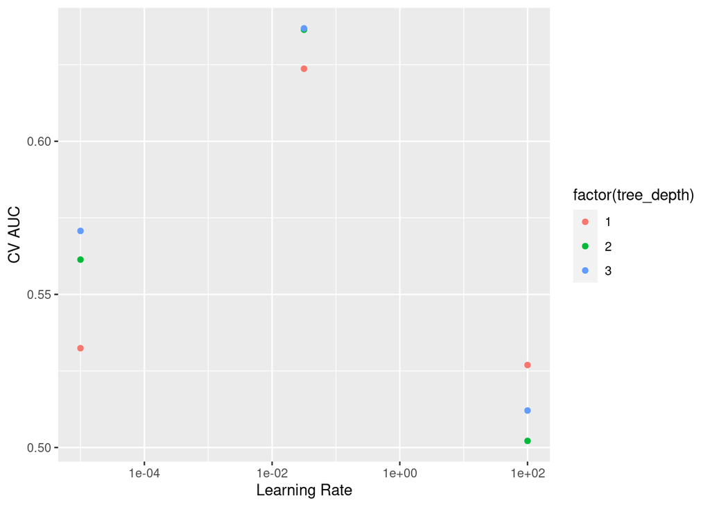

```r
gb_fit %>%
  collect_metrics() %>%
  print(width = Inf) %>%
  filter(.metric == "roc_auc") %>%
  ggplot(mapping = aes(x = learn_rate, y = mean, color = factor(tree_depth))) +
  geom_point() +
  labs(x = "Learning Rate", y = "CV AUC") +
  scale_x_log10()
```

```r
gb_fit %>%
  show_best("roc_auc")
```

```
# A tibble: 5 × 8
  tree_depth learn_rate .metric .estimator  mean     n  std_err .config
       <int>      <dbl> <chr>   <chr>      <dbl> <int>    <dbl> <chr>
1          3    0.0316  roc_auc binary     0.637     3 0.00186  Preprocessor1_M…
2          2    0.0316  roc_auc binary     0.636     3 0.00273  Preprocessor1_M…
3          1    0.0316  roc_auc binary     0.624     3 0.00356  Preprocessor1_M…
4          3    0.00001 roc_auc binary     0.571     3 0.000837 Preprocessor1_M…
5          2    0.00001 roc_auc binary     0.561     3 0.00530  Preprocessor1_M…
```

```r
best_gb <- gb_fit %>%
  select_best("roc_auc")
best_gb
```

```
# A tibble: 1 × 3
  tree_depth learn_rate .config
       <int>      <dbl> <chr>
1          3     0.0316 Preprocessor1_Model6
```

```r
# Final workflow
final_wf_gb <- gb_wf %>%
  finalize_workflow(best_gb)
final_wf_gb
```

```
══ Workflow ════════════════════════════════════════════════════════════════════
Preprocessor: Recipe
Model: boost_tree()

── Preprocessor ────────────────────────────────────────────────────────────────
5 Recipe Steps

• step_impute_mean()
• step_impute_mode()
• step_dummy()
• step_zv()
• step_normalize()

── Model ───────────────────────────────────────────────────────────────────────
Boosted Tree Model Specification (classification)

Main Arguments:
  trees = 1000
  tree_depth = 3
  learn_rate = 0.0316227766016838

Computational engine: xgboost
```

```r
final_fit_gb <-
  final_wf_gb %>%
  last_fit(data_split)
final_fit_gb
```

```
# Resampling results
# Manual resampling
# A tibble: 1 × 6
  splits                id             .metrics .notes   .predictions .workflow
  <list>                <chr>          <list>   <list>   <list>       <list>
1 <split [36590/36591]> train/test sp… <tibble> <tibble> <tibble>     <workflow>
```

The area under ROC curve and the accuracy for XGBoost model are shown below:

```r
final_fit_gb %>%
  collect_metrics()
```

```
# A tibble: 2 × 4
  .metric  .estimator .estimate .config
  <chr>    <chr>          <dbl> <chr>
1 accuracy binary         0.598 Preprocessor1_Model1
2 roc_auc  binary         0.641 Preprocessor1_Model1
```

**Answer:** 4. Model Stacking

```r
set.seed(203)
folds_stack <- vfold_cv(mimic_other, v = 2)
```

```r
# logistic regression
stack_grid_logit <- grid_regular(
  penalty(range = c(0, 3)),
  mixture(),
  levels = c(10, 5)
  )

logit_res <-
  tune_grid(
    object = logit_wf,
    resamples = folds_stack,
    grid = stack_grid_logit,
    control = control_stack_grid()
  )
```

```
ℹ The workflow being saved contains a recipe, which is 5.24 Mb in ℹ memory. If
this was not intentional, please set the control setting ℹ `save_workflow =
FALSE`.
```

```r
logit_res
```

```
# Tuning results
# 2-fold cross-validation
# A tibble: 2 × 5
  splits                id    .metrics           .notes           .predictions
  <list>                <chr> <list>             <list>           <list>
1 <split [18295/18295]> Fold1 <tibble [100 × 6]> <tibble [0 × 3]> <tibble>
2 <split [18295/18295]> Fold2 <tibble [100 × 6]> <tibble [0 × 3]> <tibble>
```

```r
# random forest
stack_grid_rf <- grid_regular(
  trees(range = c(20L, 30L)),
  mtry(range = c(1L, 2L)),
  levels = c(2, 2)
  )

rf_res <-
  tune_grid(
    object = rf_wf,
    resamples = folds_stack,
    grid = param_grid_rf,
    control = control_stack_grid()
  )
```

```
ℹ The workflow being saved contains a recipe, which is 5.24 Mb in ℹ memory. If
this was not intentional, please set the control setting ℹ `save_workflow =
FALSE`.
```

```r
rf_res
```

```
# Tuning results
# 2-fold cross-validation
# A tibble: 2 × 5
  splits                id    .metrics          .notes           .predictions
  <list>                <chr> <list>            <list>           <list>
1 <split [18295/18295]> Fold1 <tibble [18 × 6]> <tibble [0 × 3]> <tibble>
2 <split [18295/18295]> Fold2 <tibble [18 × 6]> <tibble [0 × 3]> <tibble>
```

```r
# XGBoost
stack_grid_gb <- grid_regular(
  tree_depth(range = c(1L, 2L)),
  learn_rate(range = c(-1, 0), trans = log10_trans()),
  levels = c(2, 2)
  )

gb_res <-
  tune_grid(
    object = gb_wf,
    resamples = folds_stack,
    grid = stack_grid_gb,
    control = control_stack_grid()
  )
```

```
ℹ The workflow being saved contains a recipe, which is 5.24 Mb in ℹ memory. If
this was not intentional, please set the control setting ℹ `save_workflow =
FALSE`.
```

```r
gb_res
```

```
# Tuning results
# 2-fold cross-validation
# A tibble: 2 × 5
  splits                id    .metrics         .notes           .predictions
  <list>                <chr> <list>           <list>           <list>
1 <split [18295/18295]> Fold1 <tibble [8 × 6]> <tibble [0 × 3]> <tibble>
2 <split [18295/18295]> Fold2 <tibble [8 × 6]> <tibble [0 × 3]> <tibble>
```

```r
mimic_model_st <-
  stacks() %>%
  add_candidates(logit_res) %>%
  add_candidates(rf_res) %>%
  add_candidates(gb_res) %>%
  blend_predictions(
    penalty = 10^(-4),
    metrics = c("roc_auc")
    ) %>%
  # fit the candidates with nonzero stacking coefficients
  fit_members()
mimic_model_st
```

```
── A stacked ensemble model ─────────────────────────────────────


Out of 19 possible candidate members, the ensemble retained 11.

Penalty: 1e-04.

Mixture: 1.


The 10 highest weighted member classes are:
```

```
# A tibble: 10 × 3
   member                    type         weight
   <chr>                     <chr>         <dbl>
 1 .pred_TRUE_gb_res_1_2     boost_tree   1.46
 2 .pred_TRUE_gb_res_1_1     boost_tree   1.16
 3 .pred_TRUE_rf_res_1_6     rand_forest  0.774
 4 .pred_TRUE_rf_res_1_5     rand_forest  0.545
 5 .pred_TRUE_rf_res_1_9     rand_forest  0.394
 6 .pred_TRUE_rf_res_1_3     rand_forest  0.313
 7 .pred_TRUE_rf_res_1_7     rand_forest  0.278
 8 .pred_TRUE_gb_res_1_4     boost_tree   0.151
 9 .pred_TRUE_logit_res_1_05 logistic_reg 0.128
10 .pred_TRUE_rf_res_1_4     rand_forest  0.0873
```

[output not shown]

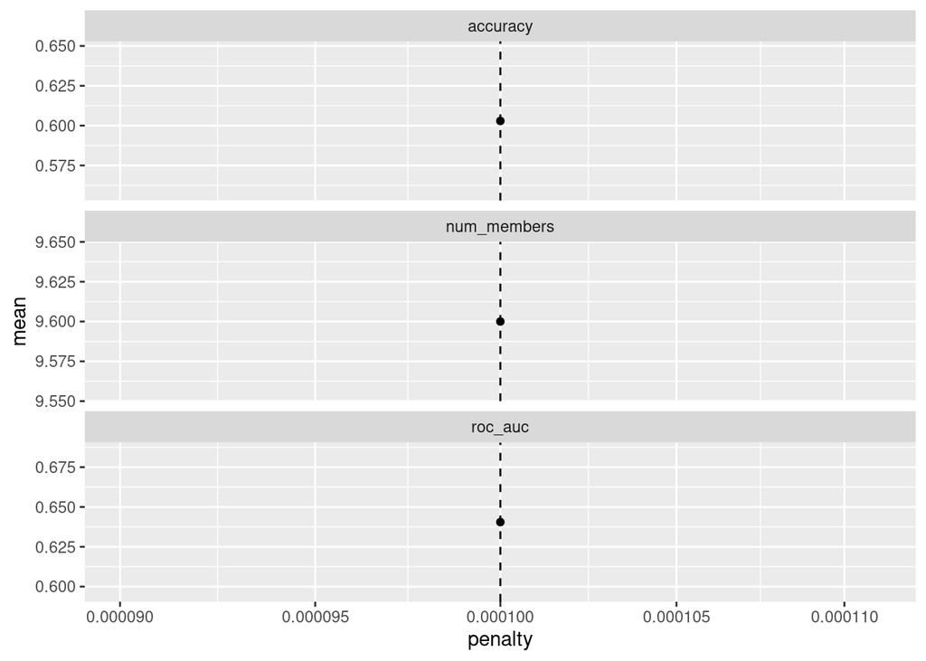

```r
autoplot(mimic_model_st)
```

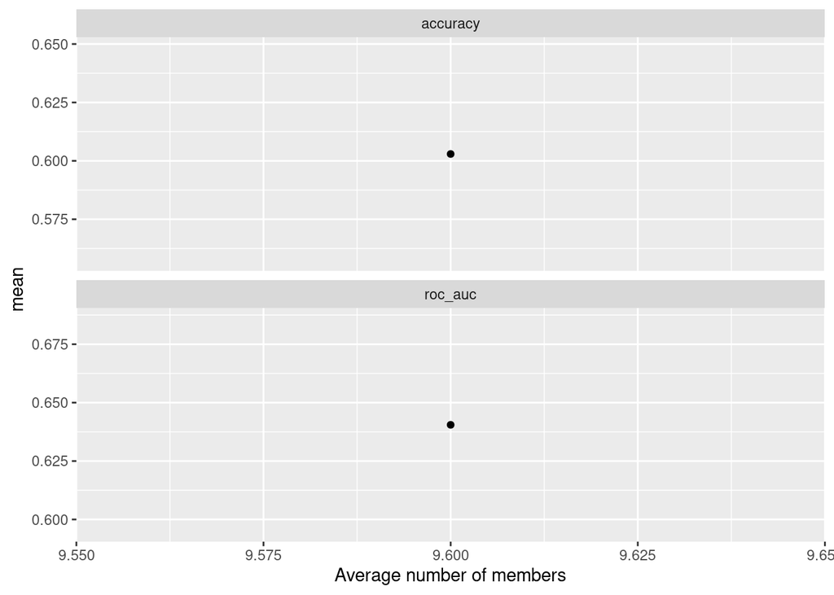

```r
autoplot(mimic_model_st, type = "members")
```

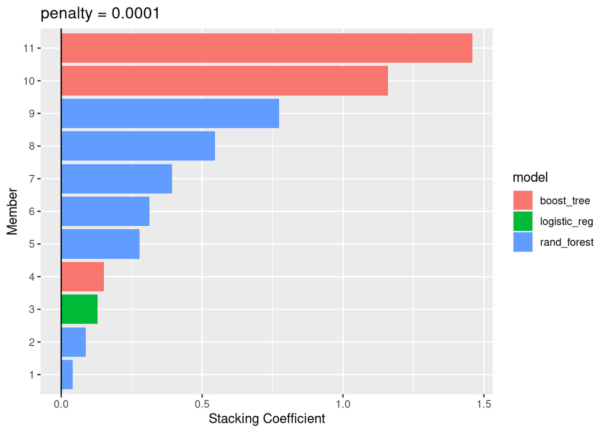

```r
autoplot(mimic_model_st, type = "weights")
```

```r
collect_parameters(mimic_model_st, "gb_res")
```

```
# A tibble: 4 × 5
  member     tree_depth learn_rate terms                  coef
  <chr>           <int>      <dbl> <chr>                 <dbl>
1 gb_res_1_1          1        0.1 .pred_TRUE_gb_res_1_1 1.16
2 gb_res_1_2          2        0.1 .pred_TRUE_gb_res_1_2 1.46
3 gb_res_1_3          1        1   .pred_TRUE_gb_res_1_3 0
4 gb_res_1_4          2        1   .pred_TRUE_gb_res_1_4 0.151
```

```r
mimic_pred <- mimic_test %>%
  bind_cols(predict(mimic_model_st, ., type = "prob")) %>%
  print(width = Inf)
```

```
# A tibble: 36,591 × 24
   los_long gender age_at_intime marital_status race
   <fct>    <chr>          <int> <chr>          <fct>
 1 FALSE    F                 76 MARRIED        BLACK
 2 FALSE    F                 55 MARRIED        WHITE
 3 FALSE    F                 55 MARRIED        WHITE
 4 TRUE     F                 77 MARRIED        BLACK
 5 TRUE     F                 81 MARRIED        WHITE
 6 TRUE     F                 77 SINGLE         WHITE
 7 TRUE     F                 81 WIDOWED        WHITE
 8 TRUE     M                 53 SINGLE         WHITE
 9 TRUE     M                 81 MARRIED        Other
10 FALSE    M                 56 <NA>           Other
   first_careunit                               creatinine sodium chloride
   <fct>                                             <dbl>  <dbl>    <dbl>
```

[output cut: 59 more lines]

The code below would compute the area under ROC curve and accuracy.

```r
yardstick::roc_auc(
  mimic_pred,
  truth = los_long,
  contains(".pred_FALSE")
  )
```

```
# A tibble: 1 × 3
  .metric .estimator .estimate
  <chr>   <chr>          <dbl>
1 roc_auc binary         0.644
```

```r
mimic_pred <-
  mimic_test %>%
  select(los_long) %>%
  bind_cols(
    predict(
      mimic_model_st,
      mimic_test,
      type = "class",
      members = TRUE
      )
    ) %>%
  print(width = Inf)
```

```
# A tibble: 36,591 × 13
   los_long .pred_class .pred_class_logit_res_1_05 .pred_class_rf_res_1_3
   <fct>    <fct>       <fct>                      <fct>
 1 FALSE    FALSE       FALSE                      FALSE
 2 FALSE    FALSE       FALSE                      FALSE
 3 FALSE    FALSE       FALSE                      FALSE
 4 TRUE     FALSE       FALSE                      FALSE
 5 TRUE     FALSE       FALSE                      FALSE
 6 TRUE     FALSE       FALSE                      FALSE
 7 TRUE     TRUE        FALSE                      TRUE
 8 TRUE     TRUE        FALSE                      FALSE
 9 TRUE     TRUE        FALSE                      TRUE
10 FALSE    FALSE       FALSE                      FALSE
   .pred_class_rf_res_1_4 .pred_class_rf_res_1_5 .pred_class_rf_res_1_6
   <fct>                  <fct>                  <fct>
```

[output cut: 35 more lines]

```r
map(
  colnames(mimic_pred),
  ~mean(mimic_pred$los_long == pull(mimic_pred, .x))
  ) %>%
  set_names(colnames(mimic_pred)) %>%
  as_tibble() %>%
  pivot_longer(c(everything(), -los_long))
```

```
# A tibble: 12 × 3
   los_long name                       value
      <dbl> <chr>                      <dbl>
 1        1 .pred_class                0.600
 2        1 .pred_class_logit_res_1_05 0.520
 3        1 .pred_class_rf_res_1_3     0.582
 4        1 .pred_class_rf_res_1_4     0.590
 5        1 .pred_class_rf_res_1_5     0.590
 6        1 .pred_class_rf_res_1_6     0.592
 7        1 .pred_class_rf_res_1_7     0.584
 8        1 .pred_class_rf_res_1_8     0.589
 9        1 .pred_class_rf_res_1_9     0.590
10        1 .pred_class_gb_res_1_1     0.593
11        1 .pred_class_gb_res_1_2     0.598
12        1 .pred_class_gb_res_1_4     0.569
```

**Answer:** Comparing all four models, random forest has a higher AUC and accuracy compared to logistic regression model; the AUC and accuracy of XGBoost and model stacking are quite similar, both higher than logistic regression model and random forest model. A higher AUC could be a good indicator of a better model, the accuracies would show us the proportion of times the model made the correct prediction. In terms of interpretability, logistic regression is generally more interpretable than other models since its coefficients can be directly linked to odds of outcome.

```r
# logistic regression
logit_model <- glm(los_long ~ ., data=mimic_other, family=binomial)
logit_importance <- abs(coef(logit_model))
logit_importance <- logit_importance / sum(logit_importance)
logit_importance <- data.frame(Feature=names(logit_importance),
                               Importance=logit_importance)
logit_importance
```

```
                                                                                                                      Feature
(Intercept)                                                                                                       (Intercept)
genderM                                                                                                               genderM
age_at_intime                                                                                                   age_at_intime
marital_statusMARRIED                                                                                   marital_statusMARRIED
marital_statusSINGLE                                                                                     marital_statusSINGLE
marital_statusWIDOWED                                                                                   marital_statusWIDOWED
raceASIAN                                                                                                           raceASIAN
raceBLACK                                                                                                           raceBLACK
raceHISPANIC                                                                                                     raceHISPANIC
raceWHITE                                                                                                           raceWHITE
first_careunitMedical Intensive Care Unit (MICU)                             first_careunitMedical Intensive Care Unit (MICU)
first_careunitMedical/Surgical Intensive Care Unit (MICU/SICU) first_careunitMedical/Surgical Intensive Care Unit (MICU/SICU)
first_careunitSurgical Intensive Care Unit (SICU)                           first_careunitSurgical Intensive Care Unit (SICU)
first_careunitOther                                                                                       first_careunitOther
creatinine                                                                                                         creatinine
sodium                                                                                                                 sodium
chloride                                                                                                             chloride
bicarbonate                                                                                                       bicarbonate
`white blood cell count`                                                                             `white blood cell count`
glucose                                                                                                               glucose
potassium                                                                                                           potassium
hematocrit                                                                                                         hematocrit
`systolic non-invasive blood pressure`                                                 `systolic non-invasive blood pressure`
`body temperature in Fahrenheit`                                                             `body temperature in Fahrenheit`
`respiratory rate`                                                                                         `respiratory rate`
`diastolic non-invasive blood pressure`                                               `diastolic non-invasive blood pressure`
`heart rate`                                                                                                     `heart rate`
subject_id                                                                                                         subject_id
hadm_id                                                                                                               hadm_id
stay_id                                                                                                               stay_id
                                                                 Importance
(Intercept)                                                    3.291209e-01
genderM                                                        1.572952e-02
age_at_intime                                                  2.862076e-03
marital_statusMARRIED                                          6.526431e-03
marital_statusSINGLE                                           1.514955e-02
marital_statusWIDOWED                                          4.295218e-02
raceASIAN                                                      4.795827e-03
raceBLACK                                                      3.321543e-02
raceHISPANIC                                                   4.023072e-02
```

[output cut: 21 more lines]

**Answer:** Based on the tables above, first careunit, are the most important feature in predicting the long ICU stay, especially those stay in MICU and SICU.